# Customization Rank Test

Carl Pearson

2/27/2020

Participants ranked what would be most important to them to customize. What options are significantly higher ranked than others?

```r
#load packages
library(tidyverse)
library(rstatix)
library(ggpubr)
library(kableExtra)
knitr::opts_chunk$set(fig.width=12, fig.height=8)

#read data
dat <- read_csv("/Users/carlpearson/Documents/r_github/RHEL-Customization-Tickets/do_not_upload/cust_ranking_dat.csv",col_names = T)

#remove commas from colnames
colnames(dat) <- gsub(",",";", colnames(dat))
colnames(dat) <- gsub("-","", colnames(dat))

df_long <- dat %>%
  rename(id=`Response ID`) %>% #rename variable
  mutate(id=as.numeric(as.factor(id))) %>% #anonymize data
  pivot_longer(-id) %>% #elongate data
  mutate(name_s=str_trunc(name,width=15,side="right",ellipsis = "")) %>% #create shorter names
  na.omit() #remove NAs
```

| id | name | value | name_s |
| --- | --- | --- | --- |
| 39 | System Hardening / Certification compliance (e.g. OpenSCAP) | 1 | System Hardenin |
| 39 | Immutable; or semiimmutable OS images (e.g. rpmostree; similar to CoreOS) | 5 | Immutable; or s |
| 39 | Configure custom file system and storage layout or scheme | 2 | Configure custo |
| 39 | Options to enroll with a config management system (e.g. Red Hat Ansible or Satellite; Puppet; Chef; Salt; …) | 6 | Options to enro |
| 39 | Configure remote or network storage (iSCSI; SANs; FCoE; …) | 4 | Configure remot |
| 39 | Reusable environment specific configuration “snippets” (… for this datacenter or cloud; configure XYZ like this… ) | 3 | Reusable enviro |

The distribution of ranks shows variation across all options with ‘Configure remote…’ looking to be lowest and ‘Options to enroll…’ looking to be the highest.

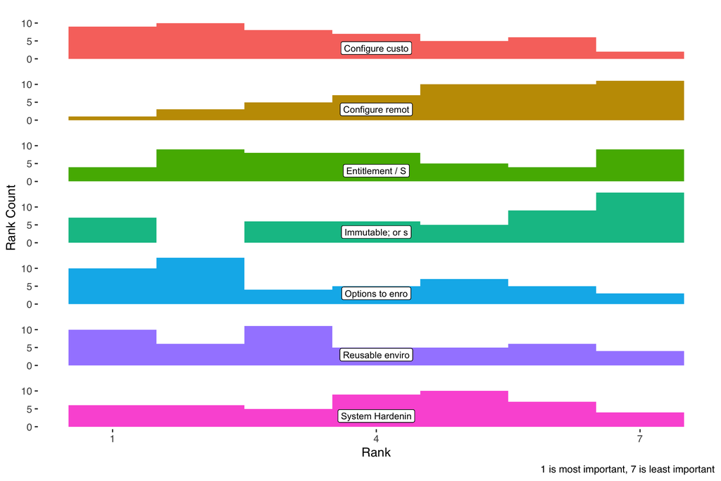

## Rank tests

With our rank data, we’ll need to use a non-parametric approach to assess statistical significance of the ranks. Our data are an unreplicated block design (where we treat blocks as participants) so we can use the Friedman test and its an exact posthoc test. Below we see that the test is signficant so ranks differ between customization options. The effect size is small, but not miniscule.

| .y. | n | statistic | df | p | method |
| --- | --- | --- | --- | --- | --- |
| value | 47 | 30.11854 | 6 | 3.73e-05 | Friedman test |

| .y. | n | effsize | method | magnitude |
| --- | --- | --- | --- | --- |
| value | 47 | 0.1068033 | Kendall W | small |

Now we need to conduct the posthoc test to see which options are statistically at a different rank. We use a pairwise Wilcoxon-Sign to see which options are significantly different from each other.

.y.

group1

group2

n1

n2

statistic

p

p.adj

p.adj.signif

value

Configure custo

Configure remot

47

47

543.0

1.80e-05

0.000378

***

value

Configure remot

Options to enro

47

47

1656.5

2.46e-05

0.000492

***

value

Configure remot

Reusable enviro

47

47

1598.0

1.63e-04

0.003000

value

Configure custo

Immutable; or s

47

47

652.0

5.47e-04

0.010000

value

Immutable; or s

Options to enro

47

47

1550.0

6.65e-04

0.011000

value

Immutable; or s

Reusable enviro

47

47

1503.5

2.00e-03

0.036000

value

Configure remot

System Hardenin

47

47

1453.0

8.00e-03

0.115000

ns

value

Configure remot

Entitlement / S

47

47

1430.0

1.30e-02

0.179000

ns

value

Immutable; or s

System Hardenin

47

47

1377.5

3.70e-02

0.481000

ns

value

Entitlement / S

Options to enro

47

47

1357.5

5.30e-02

0.637000

ns

value

Options to enro

System Hardenin

47

47

862.0

6.40e-02

0.701000

ns

value

Configure custo

System Hardenin

47

47

865.5

6.80e-02

0.701000

ns

value

Entitlement / S

Immutable; or s

47

47

866.5

6.90e-02

0.701000

ns

value

Configure custo

Entitlement / S

47

47

872.5

7.60e-02

0.701000

ns

value

Reusable enviro

System Hardenin

47

47

923.0

1.66e-01

1.000000

ns

value

Entitlement / S

Reusable enviro

47

47

1282.5

1.74e-01

1.000000

ns

value

Options to enro

Reusable enviro

47

47

1029.0

5.65e-01

1.000000

ns

value

Configure custo

Reusable enviro

47

47

1056.0

7.13e-01

1.000000

ns

value

Configure custo

Options to enro

47

47

1134.0

8.24e-01

1.000000

ns

value

Configure remot

Immutable; or s

47

47

1126.5

8.68e-01

1.000000

ns

value

Entitlement / S

System Hardenin

47

47

1099.0

9.70e-01

1.000000

ns